# text2vec package with Reddit Worldnews.

Carlos Ahumada

April 8th, 2019

# Description

Reddit is a social network which divides topics into so called ‘subreddits’. On these subreddits, users can upvote or down-vote each post. According to Reddit instructions: “[…]If you think something contributes to conversation, upvote it. If you think it does not contribute to the subreddit it is posted in or is off-topic in a particular community, downvote it”.

To test the text2vec R package, a dataset containing the title of the posts from 2008 to 2016 in the WorldNews subreddit obtained from [kaggle](https://www.kaggle.com/rootuser/worldnews-on-reddit#reddit_worldnews_start_to_2016-11-22.csv) will be used. For computational purposes, only the posts from 2016 will be taken into account.

# Data Preparation

Since the dataset does not contain a document id, I will take the time created column as the document id. However, 174 posts from the ~81k in total were created at the same time, and for so cannot be uniquely identified by this variable. For so, I will get rid of those posts that were created at the same time. By doing this transformation, I will end up with a corpus of 81,718 world news posts. Furtheremore, the feature that I will analize is whether a post was upvoted more than the median (5 upvotes) or not. This can be interpreted as a feature that indicates whether an article had big or low impact among the Reddit community.

After splitting the dataset into train and test set, let’s create the vocabulary for the creation of the DocumenT-Term-Matrix

```r
#Define preprocessing function and tokenization function
prep_fun = tolower
tok_fun = word_tokenizer
train$title <- as.character(train$title)
it_train = itoken(train$title,
             preprocessor = prep_fun,
             tokenizer = tok_fun,
             ids = train$time_created,
             progressbar = FALSE)
vocab = create_vocabulary(it_train) #Creating vocabulary for the train set
vocab
```

```
Number of docs: 57202
0 stopwords:  ...
ngram_min = 1; ngram_max = 1
Vocabulary:
```

| term | term_count | doc_count |
| --- | --- | --- |
| melioidosis | 1 | 1 |
| ducklings | 1 | 1 |
| arisen | 1 | 1 |
| 16.5b | 1 | 1 |
| immigrated | 1 | 1 |
| scone | 1 | 1 |
| fusillade | 1 | 1 |
| indicators | 1 | 1 |
| nco | 1 | 1 |
| calculated | 1 | 1 |

[output cut: 990 more lines]

# Document-Term Matrix construction

Now I create a DTM for the train set with 57202 news as the rows, and 32879 words as columns.

```r
#DTM Construction for train set
vectorizer = vocab_vectorizer(vocab)
dtm_train = create_dtm(it_train, vectorizer)
train$time_created <- as.character (train$time_created)
dim(dtm_train)
```

```
[1] 57202 32879
```

# Logistic Regression

Now I fit a logistic regression with the impact (1-above upvote median or 0-below upvote median)

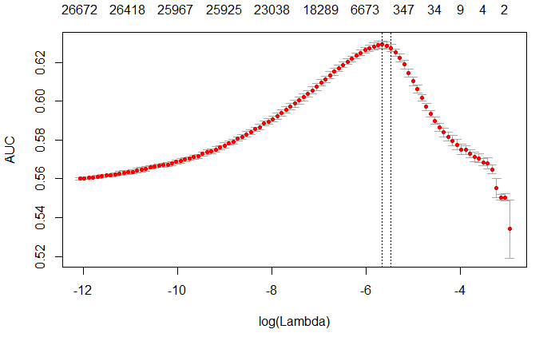

```r
library(glmnet)
NFOLDS = 4
logit = cv.glmnet(x = dtm_train, y = train[['impact']],
                              family = 'binomial',
                              # L1 penalty
                              alpha = 1,
                              # interested in the area under ROC curve
                              type.measure = "auc",
                              # 5-fold cross-validation
                              nfolds = NFOLDS,
                              # high value is less accurate, but has faster training
                              thresh = 1e-3,
                              # again lower number of iterations for faster training
                              maxit = 1e3)
plot(logit)
```

Now lets find the highest value for the AUC

```
[1] "max AUC = 0.6293"
```

Now, let’s assess the performance of the logistic regression on the test set. To do so, we have to create a DTM for the test set following the same logic as with the train set. The difference now will be the application of pipes from the magrittR package.

```r
glmnet:::auc(test$impact, preds)
```

```
[1] 0.6103007
```

The performance of the model on the test set is slightly lower than the one in the train set. However, in both sets the perfomance is rather low. This might be due to the low number of unigrams in each title. This is an indication that this particular dataset is not good to predict the impact of a post based on news. Although, the main purpose of this project is not generate models with high accuracy, but to explore the usage of the text2vec package, can we improve the acurracy by pruning the vocabulary (removing stopwords)?

```r
#pruning
stop_words = stopwords('en')
vocab = create_vocabulary(it_train, stopwords = stop_words)
pruned_vocab = prune_vocabulary(vocab,
                                 term_count_min = 1,
                                 doc_proportion_max = 0.5,
                                 doc_proportion_min = 0.001)
vectorizer = vocab_vectorizer(pruned_vocab)
# create dtm_train with new pruned vocabulary vectorizer
dtm_train  = create_dtm(it_train, vectorizer)
dim(dtm_train)
```

```
[1] 57202  1861
```

But what happens if instead of using unigrams we use bigrams? This might also help to improve the model.

Naturally, the vocabulary increases substantially. Now let’s run the logistic regression based on the new DTM with prunned vocabulary and bigrams.

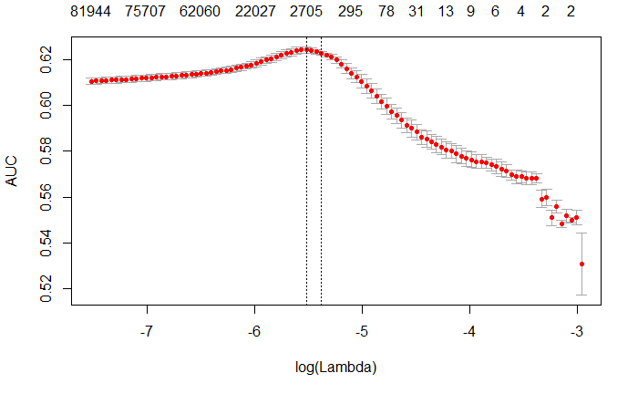

```r
logit2 = cv.glmnet(x = dtm_train, y = train[['impact']],
                 family = 'binomial',
                 alpha = 1,
                 type.measure = "auc",
                 nfolds = NFOLDS,
                 thresh = 1e-3,
                 maxit = 1e3)
plot(logit2)
```

```
[1] "max AUC = 0.6241"
```

```r
glmnet:::auc(test$impact, preds)
```

[output not shown]

# Feature Hashing

Feature Hashing is a technique developed by the Yahoo! team. This method allows to optimize the search of terms by using an algorithm that classifies observations with keys and information inside of them. the text2vec package allows to use feature hashing:

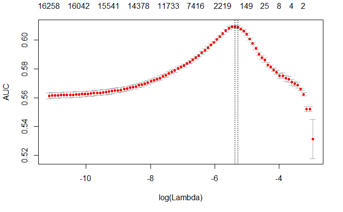

```r
#Creating hash vectorizer
h_vectorizer = hash_vectorizer(hash_size = 2 ^ 14, ngram = c(1L, 2L))
#Creating DTM with feature hashing train set
dtm_train = create_dtm(it_train, h_vectorizer)
#Running logistic regression
logit3 = cv.glmnet(x = dtm_train, y = train[['impact']],
                             family = 'binomial',
                             alpha = 1,
                             type.measure = "auc",
                             nfolds = 5,
                             thresh = 1e-3,
                             maxit = 1e3)
plot(logit3)
```

```
[1] "max AUC = 0.6095"
```

With feature hashing, the logistic model performs even worse. But let’s try the model anyway on the test set.

```r
glmnet:::auc(test$impact, preds)
```

[output not shown]

# Normalization

Normalization is a transformation that is in place when the length of the documents, in this case, the titles of the posts, differ. This adjustment might be good for the performance of models.

```r
#The L1 normalization parameter is the one that indicates that a normalization based on the length of the documents should occur.
dtm_train_norm = normalize(dtm_train, "l1")
```

# TF-IDF

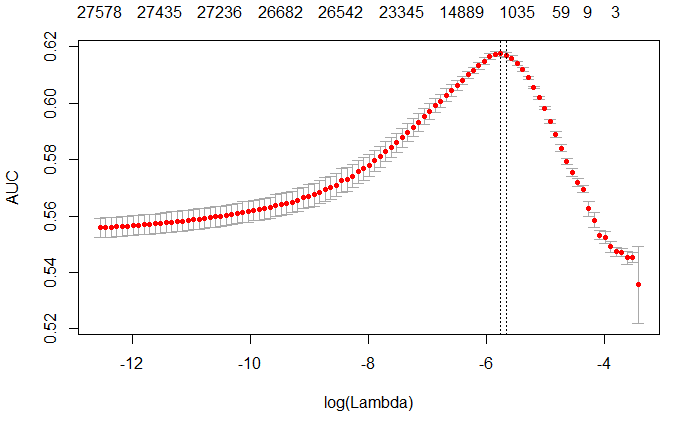

Now let´s assess the performance of the model on the test set…

```r
preds = predict(logit4, dtm_test_tfidf, type = 'response')[,1]
glmnet:::auc(test$impact, preds)
```

[output not shown]

The acurracy of the model is 60.70%, which is pretty close to the performance of the previous models. As it is stated in the text2vec guide: Usually tf-idf transformation significantly improve performance on most of the dowstream tasks.

# Collocations

The definition of collocations in Wikipedia is: “Within the area of corpus linguistics, collocation is defined as a sequence of words or terms which co-occur more often than would be expected by chance. ‘Crystal clear’, ‘middle management’, ‘nuclear family’, and ‘cosmetic surgery’ are examples of collocated pairs of words. Some words are often found together because they make up a compound noun, for example ‘riding boots’ or ‘motor cyclist’”.

| prefix | suffix | n_i | n_j | n_ij | pmi | lfmd | gensim | llr |
| --- | --- | --- | --- | --- | --- | --- | --- | --- |
| Mossack | Fonseca | 60 | 50 | 50 | 13.725849 | -14.25192 | 0.0000000 | 1015.5651 |
| Shi | ite | 59 | 54 | 53 | 13.723130 | -14.08651 | 765.4538606 | 1078.8770 |
| Dalai | Lama | 58 | 53 | 50 | 13.690694 | -14.28707 | 0.0000000 | 1000.0375 |
| Rio_de | Janeiro | 59 | 52 | 52 | 13.688273 | -14.05268 | 507.7001304 | 1060.9044 |
| Burkina | Faso | 67 | 52 | 50 | 13.510067 | -14.46770 | 0.0000000 | 976.7808 |
| Jo | Cox | 67 | 63 | 60 | 13.496261 | -13.95544 | 1925.8753850 | 1192.6930 |
| Suu | Kyi | 73 | 67 | 67 | 13.442915 | -13.69039 | 2825.4966265 | 1352.6112 |
| Puerto | Rico | 76 | 64 | 64 | 13.384812 | -13.88067 | 2339.7960526 | 1271.2337 |
| Fort | McMurray | 80 | 66 | 65 | 13.288785 | -13.93196 | 2309.4090909 | 1268.8372 |
| Jong | Un | 85 | 76 | 73 | 13.165246 | -13.72058 | 2894.2687307 | 1411.9311 |

[output cut: 308 more lines]

As it can be seen in the table above, most of the collocations refer to proper names. Mossack Fonseca, the Panamanian Law firm involved in the Panama Papers scandale is the collocation with the highest pmi score.PMI has been used for finding collocations and associations between words. For instance, countings of occurrences and co-occurrences of words in a text corpus can be used to approximate the probabilities p(x) and p(x,y) respectively.

# Naive model for collocations

Now let’s see how does the Naive model performs.The output of the code chunk below is the texts of our corpus divided

```r
it_phrases$nextElem()
```

```
$`tokens`
$`tokens`[[1]]
[1] "Protesters" "Rally"      "Against"    "Poland"     "s"          "Proposed"   "Ban"        "on"         "Abortions"

$`tokens`[[2]]
 [1] "Honduras"     "mayor"        "arrested"     "on_suspicion" "of"           "paying"       "assassins"    "to"
 [9] "murder"       "rivals"

$`tokens`[[3]]
 [1] "SitRep:"         "U.S."            "Tanks"           "in"              "Putinâs"       "Backyard;"       "Stealth"
 [8] "Planes"          "to"              "South_China_Sea"


$ids
[1] "1" "2" "3"
```

In this example, by selecting randomly three documents of the corpus and running the naive model, we find that in document number three, the words South, China, and Sea are taked as a single term grouped in “South_China_Sea”.

It might be the case that sometimes the model picks up terms like “on_suspicion” located in document 2, as a single term when in reality is not. A solution might be to remove stopwords or to keep tracking what model learned after each pass over the data. The partial fit function can be used for this purpose. This process also prunes bad phrases after each iteration.

Now, to provide an example of this method, I am going to randomly select 2000 observations from the news dataset.

| prefix | suffix | n_i | n_j | n_ij | pmi | lfmd | gensim | llr |
| --- | --- | --- | --- | --- | --- | --- | --- | --- |
| Human | Rights | 13 | 10 | 10 | 8.8964488 | -9.653472 | 238.2692308 | 134.5167956 |
| Hong | Kong | 14 | 13 | 13 | 8.7895336 | -9.003364 | 272.3076923 | 179.0980382 |
| Security | Council | 11 | 10 | 6 | 8.4004914 | -11.623361 | 56.3181818 | 66.6590781 |
| European | Union | 18 | 11 | 8 | 7.9675319 | -11.226245 | 93.8636364 | 84.8106983 |
| human | rights | 18 | 15 | 10 | 7.8420011 | -10.707920 | 114.7222222 | 104.7490096 |
| Saudi | Arabia | 28 | 12 | 12 | 7.7895336 | -10.234318 | 129.0625000 | 135.6520740 |
| refugee | camp | 14 | 14 | 7 | 7.7895336 | -11.789534 | 63.2142857 | 70.1899274 |
| At | least | 11 | 23 | 8 | 7.6138950 | -11.579882 | 73.4584980 | 79.8260117 |
| World | news | 23 | 11 | 7 | 7.4212499 | -12.157817 | 48.9723320 | 66.3232814 |
| West | Bank | 13 | 14 | 5 | 7.4110220 | -13.138899 | 0.0000000 | 45.6674343 |

[output cut: 28 more lines]

Although this model works better than the naive approach, it continues to provide some “bad phrases”. To solve this problem, one could easily manually prune the table by filtering it based on other scores such as gensim, llr or lfmd. It is important to notice that some collocations are not good because of encoding issues.

| prefix | suffix | n_i | n_j | n_ij | pmi | lfmd | gensim | llr |
| --- | --- | --- | --- | --- | --- | --- | --- | --- |
| Human | Rights | 13 | 10 | 10 | 8.896449 | -9.653472 | 238.26923 | 134.51680 |
| Hong | Kong | 14 | 13 | 13 | 8.789534 | -9.003364 | 272.30769 | 179.09804 |
| Security | Council | 11 | 10 | 6 | 8.400491 | -11.623361 | 56.31818 | 66.65908 |
| European | Union | 18 | 11 | 8 | 7.967532 | -11.226245 | 93.86364 | 84.81070 |
| human | rights | 18 | 15 | 10 | 7.842001 | -10.707920 | 114.72222 | 104.74901 |
| Saudi | Arabia | 28 | 12 | 12 | 7.789534 | -10.234318 | 129.06250 | 135.65207 |
| refugee | camp | 14 | 14 | 7 | 7.789534 | -11.789534 | 63.21429 | 70.18993 |
| At | least | 11 | 23 | 8 | 7.613895 | -11.579882 | 73.45850 | 79.82601 |
| World | news | 23 | 11 | 7 | 7.421250 | -12.157817 | 48.97233 | 66.32328 |
| air | strikes | 17 | 13 | 6 | 7.393949 | -12.629904 | 28.03167 | 55.27669 |

[output cut: 5 more lines]

Now, the collocations, although not perfect, they are cleaner than before. If we are happy with the results, we can prune learned collections. Then, one could continue training the mode as many times as necessary to obtain the desired values to obtain good collocations.

| prefix | suffix | n_i | n_j | n_ij | pmi | lfmd | gensim | llr |
| --- | --- | --- | --- | --- | --- | --- | --- | --- |
| Human | Rights | 13 | 10 | 10 | 8.896449 | -9.653472 | 238.26923 | 134.51680 |
| Hong | Kong | 14 | 13 | 13 | 8.789534 | -9.003364 | 272.30769 | 179.09804 |
| Security | Council | 11 | 10 | 6 | 8.400491 | -11.623361 | 56.31818 | 66.65908 |
| European | Union | 18 | 11 | 8 | 7.967532 | -11.226245 | 93.86364 | 84.81070 |
| human | rights | 18 | 15 | 10 | 7.842001 | -10.707920 | 114.72222 | 104.74901 |
| Saudi | Arabia | 28 | 12 | 12 | 7.789534 | -10.234318 | 129.06250 | 135.65207 |
| refugee | camp | 14 | 14 | 7 | 7.789534 | -11.789534 | 63.21429 | 70.18993 |
| At | least | 11 | 23 | 8 | 7.613895 | -11.579882 | 73.45850 | 79.82601 |
| World | news | 23 | 11 | 7 | 7.421250 | -12.157817 | 48.97233 | 66.32328 |
| air | strikes | 17 | 13 | 6 | 7.393949 | -12.629904 | 28.03167 | 55.27669 |

[output cut: 9 more lines]

# Usage

This kind of collocations can be applied in “downstream” tasks such as topic models or word embeddings. To do that, we need to create a vocabulary based on these collocations.

```r
vocabulary_with_phrases[startsWith(vocabulary_with_phrases$term, "South_"), ]
```

```
Number of docs: 2000
175 stopwords: i, me, my, myself, we, our ...
ngram_min = 1; ngram_max = 1
Vocabulary:
```

| term | term_count | doc_count |
| --- | --- | --- |
| South_China_Sea | 10 | 10 |
| South_Korea | 11 | 11 |

With this method, we can count the number of appearances of collocation that interest us, and the number of documents in which they appear.

# Word Embeddings with Collocations

Word embeddings can be understood, partially, as vector representations of words. They are useful to identify the words that appear in the ame context. By identifying words that appear in the same context we can interpret their meaning. To start creating word embeddings, we need first to create a new TCM with the words and multi-word phrases, and then train the word embeddings model.

```r
head(sort(cos_sim[,1], decreasing = TRUE), 10)
```

```
Human_Rights           UN       India:     citizens   Australian           10    Pakistani         stay      Zealand       Killed
   1.0000000    0.6733466    0.4513360    0.4106770    0.4011427    0.3824198    0.3807924    0.3725000    0.3708457    0.3602274
```

Now, using word embeddings, one can find the terms that are close to whatever collocation we want. In the example above, “Human_Rights” is very close (in terms of words embeddings) to UN, India, Citizens, Australia, and so on.

# Topic Models with Collocations

To create topic models with collocations we only need to create a DTM and fit a LDA model.

```r
v$term[word_count_per_token > 1]
```

```
[1] "refugee_camp" "air_strikes"  "human_rights"
```

By doing the process described above, we look for collocations that were found by training in the model in the larger dataset. Now we can create the dtm and fit the LDA model.

```r
N_TOPICS = 7
vectorizer = vocab_vectorizer(v)
dtm = create_dtm(it, vectorizer)
lda = LDA$new(N_TOPICS)
doc_topic = lda$fit_transform(dtm)
```